# GLOBAL NCRMP 2023 BMU Analysis

ian enochs, ben chomitz

2024-12-12

This document was created to analyze NCRMP BMU data

# 1 Data exploration

## 1.1 BAR data

### 1.1.1 Summary

There are a total of 161 bars included in this study. Sites are divided at three levels across 2 basins. The highest level (loc1) includes 2 large regions including:  
caribbean, samoa

Within these larger regions are 6 sublevels (loc2) that are generally inclusive of an island including:  
saintJohn, puertoRico, saintThomas, ofu, tau, tutuila

Most islands or loc2 level includes multiple sites (loc3) within it, totaling 21 loc3 levels across both basins

Deployment dates ranged from 2017-08-14 to 2022-05-20 and recovery dates ranged from 2023-05-18 to 2023-08-01. The deployment duration ranged from 365 to 2168 days and was on 801.9937888 days.

### 1.1.2 Calculation of stats for bar alteration by loc2

| location basin | location loc1 | location loc2 | deployment maxDays | deployment minDays | deployment n | depth maxDepth | depth minDepth | depth meanDepth | deltaMass meanDeltaMass | deltaMass sdDeltaMass | deltaMass seDeltaMass | deltaVolume meanDeltaVolume | deltaVolume sdDeltaVolume | deltaVolume seDeltaVolume | deltaDensity meanDeltaDensity | deltaDensity sdDeltaDensity | deltaDensity seDeltaDensity | macroboring meanMacroboring | macroboring sdMacroboring | macroboring seMacroboring | grazing meanGrazing | grazing sdGrazing | grazing seGrazing | accretion meanAccretion | accretion sdAccretion | accretion seAccretion |
| --- | --- | --- | --- | --- | --- | --- | --- | --- | --- | --- | --- | --- | --- | --- | --- | --- | --- | --- | --- | --- | --- | --- | --- | --- | --- | --- |
| atlantic | caribbean | puertoRico | 628 | 365 | 58 | 20.20 | 15.0000 | 18.92759 | 2.589646 | 53.91875 | 7.079879 | -39.04769 | 35.331871 | 4.639302 | 2.263482 | 1.3381991 | 0.1757141 | -6.7121768 | 5.896783 | 0.7742855 | -32.33551 | 34.516295 | 4.532212 | 18.80285 | 17.464138 | 2.2931537 |
| atlantic | caribbean | saintJohn | 538 | 482 | 37 | 15.90 | 14.5000 | 15.47027 | -14.097230 | 47.02061 | 7.730141 | -44.06473 | 45.121871 | 7.417990 | 2.546545 | 1.9681624 | 0.3235639 | -6.6813222 | 6.723934 | 1.1054080 | -37.38340 | 44.947953 | 7.389398 | 10.86408 | 5.426049 | 0.8920370 |
| atlantic | caribbean | saintThomas | 596 | 512 | 30 | 16.00 | 10.0000 | 13.83333 | 10.618635 | 16.85072 | 3.076507 | -25.55514 | 11.089828 | 2.024716 | 1.703844 | 0.3799167 | 0.0693630 | -2.1934926 | 1.551412 | 0.2832478 | -23.36165 | 10.577667 | 1.931209 | 12.50082 | 5.045293 | 0.9211403 |
| pacific | samoa | ofu | 1846 | 1841 | 8 | 15.24 | 14.6304 | 14.93520 | 13.656506 | 88.67190 | 31.350253 | -51.86102 | 31.628862 | 11.182491 | 1.575271 | 0.9883490 | 0.3494341 | -0.8737507 | 1.311972 | 0.4638523 | -50.98727 | 32.321305 | 11.427307 | 43.62279 | 42.715918 | 15.1023577 |
| pacific | samoa | tau | 1846 | 1843 | 8 | 15.24 | 14.9352 | 15.12570 | 46.310227 | 54.97315 | 19.435945 | -26.55602 | 6.872041 | 2.429634 | 1.004314 | 0.3249467 | 0.1148860 | -3.4992681 | 7.956767 | 2.8131420 | -23.05676 | 6.411421 | 2.266780 | 50.36785 | 44.578964 | 15.7610437 |
| pacific | samoa | tutuila | 1835 | 1821 | 17 | 15.24 | 14.6304 | 14.77384 | 31.009626 | 53.69875 | 13.023860 | -33.93348 | 24.989808 | 6.060919 | 1.039165 | 0.5066333 | 0.1228766 | -1.8190064 | 3.677152 | 0.8918404 | -32.11447 | 24.915831 | 6.042977 | 42.84286 | 27.579568 | 6.6890277 |

### 1.1.3 Number and deployment duration by loc3

| location basin | location loc1 | location loc2 | location loc3 | gps latitude | gps longitude | sample size n | depth maxDepth | depth minDepth | duration maxDays | duration minDays |
| --- | --- | --- | --- | --- | --- | --- | --- | --- | --- | --- |
| atlantic | caribbean | puertoRico | arecibo | 18.48227 | -66.72124 | 10 | 19.9000 | 19.9000 | 365 | 365 |
| atlantic | caribbean | puertoRico | culebra | 18.33066 | -65.33373 | 10 | 18.6000 | 18.6000 | 440 | 440 |
| atlantic | caribbean | puertoRico | fajardo | 18.33696 | -65.56462 | 10 | 19.8000 | 19.8000 | 429 | 429 |
| atlantic | caribbean | puertoRico | jobosBay | 17.91047 | -66.23161 | 10 | 19.8000 | 19.8000 | 543 | 543 |
| atlantic | caribbean | puertoRico | laParguera | 17.95355 | -67.05065 | 10 | 15.0000 | 15.0000 | 628 | 628 |
| atlantic | caribbean | puertoRico | rincon | 18.34435 | -67.26923 | 9 | 20.2000 | 20.2000 | 587 | 587 |
| atlantic | caribbean | saintJohn | johnsonsReef | 18.36316 | -64.77052 | 10 | 15.9000 | 15.9000 | 500 | 500 |
| atlantic | caribbean | saintJohn | newfound | 18.34744 | -64.66539 | 10 | 15.6000 | 15.6000 | 2166 | 485 |
| atlantic | caribbean | saintJohn | stevenCay | 18.32802 | -64.80903 | 9 | 14.5000 | 14.5000 | 2168 | 482 |
| atlantic | caribbean | saintJohn | tektite | 18.30976 | -64.72299 | 10 | 15.7000 | 15.7000 | 538 | 538 |
| atlantic | caribbean | saintThomas | brewersBay | 18.34435 | -64.98433 | 10 | 10.0000 | 10.0000 | 596 | 596 |
| atlantic | caribbean | saintThomas | innerBrass | 18.38262 | -64.97816 | 10 | 15.5000 | 15.5000 | 524 | 517 |
| atlantic | caribbean | saintThomas | savana | 18.34082 | -65.08269 | 10 | 16.0000 | 16.0000 | 512 | 512 |
| pacific | samoa | ofu | OCC-OFU-002 | 19.24430 | -155.90028 | 4 | 14.6304 | 14.6304 | 1846 | 1846 |
| pacific | samoa | ofu | OCC-OFU-009 | -0.38241 | -160.00293 | 4 | 15.2400 | 15.2400 | 1841 | 1841 |
| pacific | samoa | tau | OCC-TAU-002 | 5.89733 | -162.07817 | 3 | 14.9352 | 14.9352 | 1846 | 1846 |
| pacific | samoa | tau | OCC-TAU-011 | -14.18059 | -169.65211 | 5 | 15.2400 | 15.2400 | 1843 | 1843 |
| pacific | samoa | tutuila | OCC-TUT-002 | -14.28537 | -170.56395 | 2 | 14.6304 | 14.6304 | 1835 | 1835 |
| pacific | samoa | tutuila | OCC-TUT-002 | -0.36896 | -160.00826 | 3 | 14.6304 | 14.6304 | 1835 | 1835 |
| pacific | samoa | tutuila | OCC-TUT-007 | 5.88323 | -162.13318 | 4 | 14.6304 | 14.6304 | 1821 | 1821 |
| pacific | samoa | tutuila | OCC-TUT-017 | -14.28537 | -170.56395 | 2 | 14.6304 | 14.6304 | 1823 | 1823 |
| pacific | samoa | tutuila | OCC-TUT-017 | -0.36896 | -160.00826 | 2 | 14.6304 | 14.6304 | 1823 | 1823 |
| pacific | samoa | tutuila | OCC-TUT-022 | -14.21240 | -169.44067 | 4 | 15.2400 | 15.2400 | 1829 | 1829 |

### 1.1.4 Deployment sites with multiple gps coordinates

Note: need to figure out what is going on here. Appears to be particularly prevalent of a problem in the Pacific (point for alliteration)

| basin | loc1 | loc2 | loc3 | latitude | longitude | n | maxDepth | minDepth | maxDays | minDays |
| --- | --- | --- | --- | --- | --- | --- | --- | --- | --- | --- |
| pacific | samoa | tutuila | OCC-TUT-002 | -14.28537 | -170.5640 | 2 | 14.6304 | 14.6304 | 1835 | 1835 |
| pacific | samoa | tutuila | OCC-TUT-002 | -0.36896 | -160.0083 | 3 | 14.6304 | 14.6304 | 1835 | 1835 |
| pacific | samoa | tutuila | OCC-TUT-017 | -14.28537 | -170.5640 | 2 | 14.6304 | 14.6304 | 1823 | 1823 |
| pacific | samoa | tutuila | OCC-TUT-017 | -0.36896 | -160.0083 | 2 | 14.6304 | 14.6304 | 1823 | 1823 |

## 1.2 Parrot fish community

### 1.2.1 Summary

There are a total of 1225 parrot surveys included in this study. Sites are divided at three levels across 2 basins. The highest level (loc1) includes 8 large regions including:  
florida, flowerGardenBanks, caribbean, marianas, middleHawaiianIslands, northwestHawaiianIslands, pacificRemoteIslandArea, samoa

### 1.2.2 Calculation of stats for parrot fish density and biomass

| location basin | location loc1 | location loc2 | deployment n | density meanDensity_ind_ha | density sdDensity_ind_ha | density seDensity_ind_ha | biomass meanBiomass_kg_ha | biomass sdBiomass_kg_ha | biomass seBiomass_kg_ha |
| --- | --- | --- | --- | --- | --- | --- | --- | --- | --- |
| atlantic | caribbean | puertoRico | 87 | 325.34580 | 420.5386 | 45.08647 | 16.84333 | 24.91602 | 2.671277 |
| atlantic | caribbean | saintCroix | 105 | 465.16008 | 507.5089 | 49.52780 | 35.62523 | 40.61540 | 3.963657 |
| atlantic | caribbean | saintJohn | 49 | 929.32088 | 741.2058 | 105.88654 | 27.67571 | 29.57631 | 4.225187 |
| atlantic | caribbean | saintThomas | 38 | 1141.83765 | 2605.2740 | 422.63124 | 32.97925 | 44.43734 | 7.208688 |
| atlantic | florida | dryTortugas | 22 | 1003.43220 | 477.4532 | 101.79337 | 46.99733 | 70.25396 | 14.978194 |
| atlantic | florida | keys | 123 | 838.32736 | 857.1151 | 77.28346 | 81.55739 | 148.55909 | 13.395122 |
| atlantic | flowerGardenBanks | flowerGardenBanks | 41 | 212.89789 | 118.0199 | 18.43161 | 65.17329 | 42.91670 | 6.702463 |
| pacific | marianas | guam | 71 | 162.19358 | 161.8297 | 19.20566 | 35.17649 | 48.15764 | 5.715260 |
| pacific | marianas | maug | 62 | 205.36122 | 151.0224 | 19.17987 | 104.17208 | 95.41819 | 12.118122 |
| pacific | marianas | pagan | 47 | 211.90559 | 223.2471 | 32.56394 | 140.23714 | 146.76278 | 21.407552 |
| pacific | marianas | saipan | 56 | 219.28014 | 238.2128 | 31.83252 | 39.88110 | 91.49567 | 12.226623 |
| pacific | middleHawaiianIslands | hawaii | 59 | 103.58559 | 117.3219 | 15.27401 | 89.65356 | 189.93594 | 24.727553 |
| pacific | middleHawaiianIslands | oahu | 75 | 68.66062 | 107.2050 | 12.37896 | 23.34395 | 80.43737 | 9.288107 |
| pacific | northwestHawaiianIslands | frenchFrigateShoals | 63 | 258.24082 | 285.7798 | 36.00487 | 82.64512 | 141.73259 | 17.856628 |
| pacific | northwestHawaiianIslands | pearlHermes | 54 | 589.98672 | 656.2887 | 89.30958 | 109.03720 | 103.97793 | 14.149604 |
| pacific | pacificRemoteIslandArea | jarvis | 74 | 252.73614 | 265.9322 | 30.91399 | 187.76332 | 134.49823 | 15.635102 |
| pacific | pacificRemoteIslandArea | palmyra | 35 | 247.37225 | 142.3575 | 24.06281 | 98.90607 | 113.76370 | 19.229574 |
| pacific | pacificRemoteIslandArea | wake | 48 | 209.84874 | 227.5420 | 32.84287 | 81.03254 | 131.57821 | 18.991679 |
| pacific | samoa | ofu | 24 | 404.37145 | 399.4858 | 81.54470 | 226.07912 | 263.73687 | 53.835063 |
| pacific | samoa | tau | 27 | 137.27933 | 113.3681 | 21.81771 | 108.69679 | 124.77737 | 24.013417 |
| pacific | samoa | tutuila | 65 | 255.51850 | 238.7243 | 29.61010 | 88.91541 | 157.64428 | 19.553366 |

### 1.2.3 Number of parrot fish surveys by loc3

| basin | loc1 | loc2 | loc3 | n |
| --- | --- | --- | --- | --- |
| atlantic | caribbean | puertoRico | culebra | 11 |
| atlantic | caribbean | puertoRico | fajardo | 29 |
| atlantic | caribbean | puertoRico | jobosBay | 12 |
| atlantic | caribbean | puertoRico | laParguera | 18 |
| atlantic | caribbean | puertoRico | rincon | 17 |
| atlantic | caribbean | saintCroix | langBank | 32 |
| atlantic | caribbean | saintCroix | saltRiver | 37 |
| atlantic | caribbean | saintCroix | south | 20 |
| atlantic | caribbean | saintCroix | spratHole | 16 |
| atlantic | caribbean | saintJohn | johnsonsReef | 13 |
| atlantic | caribbean | saintJohn | newfound | 13 |
| atlantic | caribbean | saintJohn | stevenCay | 10 |
| atlantic | caribbean | saintJohn | tektite | 13 |
| atlantic | caribbean | saintThomas | brewersBay | 12 |
| atlantic | caribbean | saintThomas | innerBrass | 14 |
| atlantic | caribbean | saintThomas | sava | 12 |
| atlantic | florida | dryTortugas | birdKeyReef | 22 |
| atlantic | florida | keys | NA | 123 |
| atlantic | flowerGardenBanks | flowerGardenBanks | eastBank | 41 |
| pacific | marianas | guam | OCC-GUA-002 | 14 |
| pacific | marianas | guam | OCC-GUA-005 | 10 |
| pacific | marianas | guam | OCC-GUA-009 | 31 |
| pacific | marianas | guam | OCC-GUA-015 | 16 |
| pacific | marianas | maug | OCC-MAU-002 | 10 |
| pacific | marianas | maug | OCC-MAU-005 | 11 |
| pacific | marianas | maug | OCC-MAU-008 | 10 |
| pacific | marianas | maug | OCC-MAU-016 | 10 |
| pacific | marianas | maug | OCC-MAU-018 | 10 |
| pacific | marianas | maug | OCC-MAU-019 | 11 |
| pacific | marianas | pagan | OCC-PAG-002 | 14 |
| pacific | marianas | pagan | OCC-PAG-006 | 11 |
| pacific | marianas | pagan | OCC-PAG-009 | 12 |
| pacific | marianas | pagan | OCC-PAG-013 | 10 |
| pacific | marianas | saipan | OCC-SAI-002 | 11 |
| pacific | marianas | saipan | OCC-SAI-005 | 11 |
| pacific | marianas | saipan | OCC-SAI-009 | 10 |
| pacific | marianas | saipan | OCC-SAI-012 | 13 |
| pacific | marianas | saipan | OCC-SAI-016 | 11 |
| pacific | middleHawaiianIslands | hawaii | OCC-HAW-002 | 13 |
| pacific | middleHawaiianIslands | hawaii | OCC-HAW-008 | 10 |
| pacific | middleHawaiianIslands | hawaii | OCC-HAW-010 | 13 |
| pacific | middleHawaiianIslands | hawaii | OCC-HAW-014 | 13 |
| pacific | middleHawaiianIslands | hawaii | OCC-HAW-066 | 10 |
| pacific | middleHawaiianIslands | oahu | OCC-OAH-002 | 10 |
| pacific | middleHawaiianIslands | oahu | OCC-OAH-005 | 10 |
| pacific | middleHawaiianIslands | oahu | OCC-OAH-007 | 10 |
| pacific | middleHawaiianIslands | oahu | OCC-OAH-008 | 14 |
| pacific | middleHawaiianIslands | oahu | OCC-OAH-010 | 11 |
| pacific | middleHawaiianIslands | oahu | OCC-OAH-012 | 10 |
| pacific | middleHawaiianIslands | oahu | OCC-OAH-014 | 10 |
| pacific | northwestHawaiianIslands | frenchFrigateShoals | OCC-FFS-002 | 16 |
| pacific | northwestHawaiianIslands | frenchFrigateShoals | OCC-FFS-004 | 16 |
| pacific | northwestHawaiianIslands | frenchFrigateShoals | OCC-FFS-007 | 11 |
| pacific | northwestHawaiianIslands | frenchFrigateShoals | OCC-FFS-010 | 10 |
| pacific | northwestHawaiianIslands | frenchFrigateShoals | OCC-FFS-014 | 10 |
| pacific | northwestHawaiianIslands | pearlHermes | OCC-PHR-002 | 11 |
| pacific | northwestHawaiianIslands | pearlHermes | OCC-PHR-007 | 11 |
| pacific | northwestHawaiianIslands | pearlHermes | OCC-PHR-012 | 11 |
| pacific | northwestHawaiianIslands | pearlHermes | OCC-PHR-016 | 21 |
| pacific | pacificRemoteIslandArea | jarvis | OCC-JAR-003 | 28 |
| pacific | pacificRemoteIslandArea | jarvis | OCC-JAR-008 | 20 |
| pacific | pacificRemoteIslandArea | jarvis | OCC-JAR-013 | 26 |
| pacific | pacificRemoteIslandArea | palmyra | OCC-PAL-003 | 10 |
| pacific | pacificRemoteIslandArea | palmyra | OCC-PAL-008 | 10 |
| pacific | pacificRemoteIslandArea | palmyra | OCC-PAL-017 | 15 |
| pacific | pacificRemoteIslandArea | wake | OCC-WAK-002 | 13 |
| pacific | pacificRemoteIslandArea | wake | OCC-WAK-005 | 11 |
| pacific | pacificRemoteIslandArea | wake | OCC-WAK-008 | 10 |
| pacific | pacificRemoteIslandArea | wake | OCC-WAK-013 | 14 |
| pacific | samoa | ofu | OCC-OFU-002 | 11 |
| pacific | samoa | ofu | OCC-OFU-009 | 13 |
| pacific | samoa | tau | OCC-TAU-002 | 15 |
| pacific | samoa | tau | OCC-TAU-011 | 12 |
| pacific | samoa | tutuila | OCC-TUT-002 | 11 |
| pacific | samoa | tutuila | OCC-TUT-007 | 25 |
| pacific | samoa | tutuila | OCC-TUT-017 | 19 |
| pacific | samoa | tutuila | OCC-TUT-022 | 10 |

### 1.2.4 Graph parrot biomass vs. density

Combine bar stats and parrot community stats tables

Mean parrot biomass_kg_ha vs parrot density_ind_ha

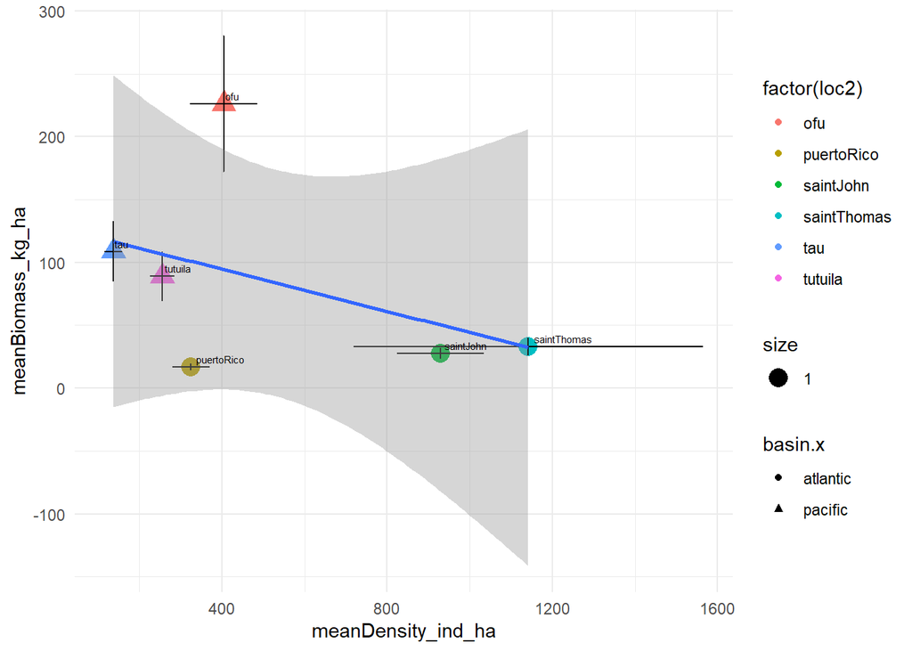

## 1.3 Environmental data

Table of summary statistics for loc2 sites

| basin | loc1 | loc2 | loc3 | lat | lon | maxDate | minDate | n | maxTemperature | minTemperature | meanTemperature | maxSalinity | minSalinity | meanSalinity | maxPAR | minPAR | meanPAR |
| --- | --- | --- | --- | --- | --- | --- | --- | --- | --- | --- | --- | --- | --- | --- | --- | --- | --- |
| atlantic | caribbean | puertoRico | culebra | 18.33066 | -65.33373 | 15/12/2021 | 15/01/2017 | 60 | 29.55867 | 26.16267 | 27.78267 | 39.14560 | 34.58726 | 36.28825 | 57.16560 | 34.40720 | 45.89707 |
| atlantic | caribbean | puertoRico | fajardo | 18.33696 | -65.56462 | 15/12/2021 | 15/01/2017 | 60 | 29.64167 | 26.14400 | 27.82349 | 39.14560 | 34.58726 | 36.28825 | 56.73400 | 33.88800 | 45.88687 |
| atlantic | caribbean | puertoRico | jobosBay | 17.91047 | -66.23161 | 15/12/2021 | 15/01/2017 | 56 | 29.65833 | 26.15633 | 28.01349 | 38.78876 | 31.96724 | 36.29282 | 57.39200 | 35.30440 | 47.86539 |
| atlantic | caribbean | puertoRico | laParguera | 17.95355 | -67.05065 | 15/12/2021 | 15/01/2015 | 78 | 29.80867 | 26.35633 | 28.09554 | 39.33810 | 27.49867 | 34.94246 | 57.05850 | 32.27050 | 47.19786 |
| atlantic | caribbean | puertoRico | rincon | 18.34435 | -67.26923 | 15/12/2021 | 15/01/2017 | 56 | 29.59900 | 26.23800 | 28.06245 | 38.73786 | 34.73122 | 36.77095 | 52.86000 | 30.96850 | 42.38671 |
| atlantic | caribbean | saintCroix | langBank | 17.82805 | -64.46711 | 15/12/2021 | 15/01/2016 | 79 | 29.55867 | 26.08933 | 27.82354 | 37.19409 | 33.60120 | 35.75669 | 58.27150 | 33.80350 | 47.32692 |
| atlantic | caribbean | saintCroix | saltRiver | 17.78532 | -64.75953 | 15/12/2021 | 15/01/2014 | 103 | 29.57033 | 26.09100 | 27.77689 | 37.19809 | 33.62944 | 35.81677 | 57.24733 | 31.98333 | 46.47610 |
| atlantic | caribbean | saintCroix | south | 17.70121 | -64.64793 | 15/12/2021 | 15/01/2016 | 79 | 29.57200 | 26.11067 | 27.82726 | 37.35077 | 33.66517 | 35.76936 | 57.98533 | 32.46400 | 47.37468 |
| atlantic | caribbean | saintCroix | spratHole | 17.73380 | -64.89639 | 15/12/2021 | 15/01/2016 | 79 | 29.58533 | 26.13267 | 27.84178 | 37.31226 | 33.67678 | 35.76740 | 55.44600 | 29.53467 | 44.07132 |
| atlantic | caribbean | saintThomas | brewersBay | 18.34402 | -64.98453 | 15/12/2021 | 15/01/2015 | 86 | 29.55533 | 26.09167 | 27.80852 | 39.14560 | 34.58726 | 36.36394 | 57.79300 | 29.33600 | 45.53676 |
| atlantic | caribbean | saintThomas | innerBrass | 18.38262 | -64.97816 | 15/12/2021 | 15/01/2017 | 60 | 29.56733 | 26.08900 | 27.75317 | 39.14560 | 34.58726 | 36.28825 | 58.05400 | 33.69950 | 46.38738 |
| atlantic | caribbean | saintThomas | sava | 18.34082 | -65.08269 | 15/12/2021 | 15/01/2017 | 60 | 29.56233 | 26.13100 | 27.78427 | 39.14560 | 34.58726 | 36.28825 | 56.08533 | 33.17800 | 44.51777 |
| atlantic | florida | keys | LKI2 | 24.57899 | -81.49734 | 15/12/2021 | 15/01/2016 | 79 | 30.76200 | 22.62333 | 27.06701 | 38.09564 | 34.95231 | 36.68801 | 59.00033 | 22.44567 | 44.32170 |
| atlantic | florida | keys | LKO1 | 24.52202 | -81.57709 | 15/12/2021 | 15/01/2016 | 79 | 30.65767 | 22.74900 | 27.09566 | 37.86179 | 34.52498 | 36.53836 | 59.42500 | 23.06700 | 44.24081 |
| atlantic | florida | keys | LKO2 | 24.55326 | -81.43753 | 15/12/2021 | 15/01/2016 | 79 | 30.73567 | 22.71400 | 27.09538 | 38.09564 | 34.95231 | 36.68801 | 58.84217 | 21.98483 | 44.34031 |
| atlantic | florida | keys | MKI1 | 24.68554 | -81.04336 | 15/12/2021 | 15/01/2016 | 79 | 30.69467 | 22.67633 | 27.09894 | 38.55490 | 34.55724 | 36.79383 | 58.75733 | 22.80667 | 44.25287 |
| atlantic | florida | keys | MKI2 | 24.68988 | -81.02940 | 15/12/2021 | 15/01/2016 | 79 | 30.69467 | 22.67633 | 27.09894 | 38.55490 | 34.55724 | 36.79383 | 58.75733 | 22.80667 | 44.25287 |
| atlantic | florida | keys | MKO1 | 24.63127 | -81.09255 | 15/12/2021 | 15/01/2016 | 79 | 30.57033 | 22.91033 | 27.13954 | 38.55490 | 34.55724 | 36.79383 | 58.95467 | 22.93533 | 44.27389 |
| atlantic | florida | keys | MKO2 | 24.63388 | -81.08344 | 15/12/2021 | 15/01/2016 | 79 | 30.57033 | 22.91033 | 27.13954 | 38.55490 | 34.55724 | 36.79383 | 58.95467 | 22.93533 | 44.27389 |
| atlantic | florida | keys | UKI2 | 24.95375 | -80.54806 | 15/12/2021 | 15/01/2016 | 78 | 30.62300 | 23.15067 | 27.19368 | 38.70824 | 34.30801 | 36.99134 | 58.46350 | 22.62400 | 44.02179 |
| atlantic | florida | keys | UKO1 | 24.90250 | -80.53104 | 15/12/2021 | 15/01/2016 | 78 | 30.46833 | 23.37133 | 27.22422 | 38.70824 | 34.30801 | 36.99134 | 58.25088 | 22.37050 | 44.03965 |
| atlantic | florida | keys | UKO3 | 24.88266 | -80.56088 | 15/12/2021 | 15/01/2016 | 78 | 30.44667 | 23.39467 | 27.23236 | 38.70824 | 34.30801 | 36.99134 | 58.36247 | 22.54112 | 44.04670 |
| atlantic | florida | keys | cheecaRocks | 24.89742 | -80.61573 | 15/12/2021 | 15/01/2013 | 113 | 30.66667 | 23.17900 | 27.14902 | 38.88633 | 34.30801 | 36.97306 | 58.46350 | 22.62400 | 43.25230 |
| atlantic | flowerGardenBanks | flowerGardenBanks | eastBank | 27.90740 | -93.59925 | 15/12/2021 | 15/01/2015 | 90 | 30.71700 | 20.37733 | 25.54828 | 37.46044 | 30.19611 | 34.89411 | 60.33400 | 17.77200 | 39.22562 |
| pacific | marianas | guam | OCC-GUA-005 | 13.47516 | 144.86485 | 15/12/2021 | 15/01/2014 | 103 | 30.22367 | 27.12567 | 28.86750 | 35.03508 | 32.39564 | 33.72445 | 56.67400 | 34.13600 | 44.33913 |
| pacific | marianas | guam | NA | 13.24126 | 144.70442 | 15/12/2021 | 15/01/2014 | 103 | 30.25300 | 27.14067 | 28.91133 | 35.11860 | 33.15658 | 34.03647 | 56.58000 | 33.95467 | 44.66653 |
| pacific | marianas | guam | NA | 13.52894 | 144.80037 | 15/12/2021 | 15/01/2014 | 102 | 30.21900 | 27.13467 | 28.84329 | 34.72307 | 32.18224 | 33.67773 | 55.53400 | 32.96700 | 43.42567 |
| pacific | marianas | guam | NA | 13.60330 | 144.92365 | 15/12/2021 | 15/01/2014 | 102 | 30.24267 | 27.11733 | 28.85499 | 34.72307 | 32.18224 | 33.67773 | 55.17700 | 33.53600 | 44.42393 |
| pacific | marianas | maug | NA | 20.01312 | 145.20806 | 15/12/2021 | 15/01/2014 | 99 | 30.87433 | 25.11633 | 28.31862 | 36.06712 | 33.62441 | 34.55486 | 59.44800 | 28.38800 | 44.80622 |
| pacific | marianas | maug | NA | 20.01398 | 145.22746 | 15/12/2021 | 15/01/2017 | 66 | 30.35500 | 25.64900 | 28.39455 | 36.06712 | 33.62441 | 34.47699 | 59.07350 | 30.70975 | 45.17994 |
| pacific | marianas | maug | NA | 20.02033 | 145.23972 | 15/12/2021 | 15/01/2014 | 99 | 30.87433 | 25.11633 | 28.31862 | 36.06712 | 33.62441 | 34.55486 | 59.07350 | 28.48100 | 45.11780 |
| pacific | marianas | maug | NA | 20.02249 | 145.22971 | 15/12/2021 | 15/01/2017 | 66 | 30.35500 | 25.64900 | 28.39455 | 36.06712 | 33.62441 | 34.47699 | 59.07350 | 30.70975 | 45.17994 |
| pacific | marianas | maug | NA | 20.02296 | 145.22996 | 15/12/2021 | 15/01/2017 | 66 | 30.35500 | 25.64900 | 28.39455 | 36.06712 | 33.62441 | 34.47699 | 59.07350 | 30.70975 | 45.17994 |
| pacific | marianas | maug | NA | 20.03570 | 145.22467 | 15/12/2021 | 15/01/2014 | 99 | 30.87433 | 25.11633 | 28.31862 | 36.06712 | 33.62441 | 34.55486 | 59.07350 | 28.48100 | 45.11780 |
| pacific | marianas | pagan | NA | 18.04564 | 145.70623 | 15/12/2021 | 15/01/2014 | 103 | 30.58700 | 26.26533 | 28.63017 | 35.17295 | 33.46750 | 34.36366 | 57.09600 | 25.62000 | 43.41293 |
| pacific | marianas | pagan | NA | 18.09612 | 145.76486 | 15/12/2021 | 15/01/2014 | 103 | 30.60000 | 26.21467 | 28.61807 | 36.18639 | 33.33631 | 34.35146 | 57.28067 | 26.93133 | 44.01817 |
| pacific | marianas | pagan | NA | 18.12014 | 145.75466 | 15/12/2021 | 15/01/2014 | 103 | 30.61733 | 26.17025 | 28.61298 | 36.18639 | 33.33631 | 34.35146 | 57.28067 | 26.93133 | 44.01817 |
| pacific | marianas | pagan | NA | 18.16784 | 145.79495 | 15/12/2021 | 15/01/2014 | 103 | 30.63233 | 26.12533 | 28.60394 | 36.18639 | 33.33631 | 34.35146 | 58.72200 | 27.96800 | 44.47614 |
| pacific | marianas | saipan | NA | 15.09785 | 145.74337 | 15/12/2021 | 15/01/2014 | 103 | 30.29200 | 26.95933 | 28.75117 | 35.18739 | 33.44971 | 34.24299 | 56.57467 | 33.89000 | 45.42712 |
| pacific | marianas | saipan | NA | 15.15645 | 145.68970 | 15/12/2021 | 15/01/2014 | 103 | 30.25700 | 26.94067 | 28.73052 | 35.18739 | 33.44971 | 34.24299 | 56.26156 | 33.28067 | 44.44965 |
| pacific | marianas | saipan | NA | 15.25719 | 145.76675 | 15/12/2021 | 15/01/2017 | 67 | 30.32133 | 26.98633 | 28.78051 | 34.88993 | 33.55919 | 34.17502 | 57.15450 | 35.51120 | 46.39015 |
| pacific | marianas | saipan | NA | 15.25866 | 145.81569 | 15/12/2021 | 15/01/2014 | 103 | 30.34400 | 26.92233 | 28.77355 | 35.01051 | 33.21275 | 34.19024 | 56.97400 | 33.92880 | 45.52164 |
| pacific | marianas | saipan | NA | 15.29062 | 145.80941 | 15/12/2017 | 15/01/2014 | 48 | 30.34400 | 26.92233 | 28.79967 | 35.01051 | 33.21275 | 34.22077 | 54.14800 | 33.92880 | 43.90238 |
| pacific | middleHawaiianIslands | hawaii | NA | 19.06075 | -155.55231 | 15/12/2016 | 15/01/2013 | 48 | 28.23267 | 23.55500 | 25.80121 | 36.05416 | 32.19949 | 34.27189 | 47.58500 | 23.74400 | 38.30583 |
| pacific | middleHawaiianIslands | hawaii | NA | 19.24432 | -155.90024 | 15/12/2019 | 15/01/2013 | 84 | 28.67000 | 24.29700 | 26.29705 | 36.24085 | 32.19949 | 34.13069 | 52.25800 | 24.06533 | 38.86551 |
| pacific | middleHawaiianIslands | hawaii | NA | 19.48642 | -154.81760 | 15/12/2016 | 15/01/2013 | 48 | 28.04667 | 23.36967 | 25.70820 | 33.93440 | 31.07292 | 32.58683 | 54.37200 | 23.63300 | 42.24586 |
| pacific | middleHawaiianIslands | hawaii | NA | 20.24913 | -155.89095 | 15/12/2019 | 15/01/2013 | 75 | 28.46767 | 23.92000 | 25.96344 | 35.42809 | 29.36302 | 32.64477 | 58.32083 | 30.97600 | 45.80875 |
| pacific | middleHawaiianIslands | hawaii | NA | 20.26828 | -155.86040 | 15/12/2019 | 15/01/2013 | 75 | 28.45833 | 23.89167 | 25.94135 | 35.42809 | 29.36302 | 32.64477 | 57.76133 | 31.15067 | 45.30707 |
| pacific | middleHawaiianIslands | oahu | NA | 21.26184 | -157.76547 | 15/12/2016 | 15/01/2013 | 36 | 28.32867 | 23.51667 | 25.63839 | 38.34129 | 31.58331 | 34.57421 | 57.11200 | 27.82800 | 47.34444 |
| pacific | middleHawaiianIslands | oahu | NA | 21.28838 | -157.86542 | 15/12/2019 | 15/01/2013 | 59 | 28.45067 | 23.39867 | 25.96151 | 38.34129 | 31.58331 | 34.44019 | 57.53000 | 29.07900 | 47.73870 |
| pacific | middleHawaiianIslands | oahu | NA | 21.30566 | -158.12622 | 15/12/2016 | 15/01/2013 | 44 | 28.54800 | 24.03267 | 26.02330 | 36.84579 | 33.08838 | 34.59792 | 52.55850 | 27.72850 | 43.36538 |
| pacific | middleHawaiianIslands | oahu | NA | 21.45862 | -157.79865 | 15/12/2019 | 15/03/2017 | 23 | 27.64767 | 23.18400 | 25.87559 | 36.89705 | 32.20330 | 34.23041 | 56.79250 | 29.30550 | 44.12433 |
| pacific | middleHawaiianIslands | oahu | NA | 21.47972 | -157.78294 | 15/12/2019 | 15/01/2013 | 59 | 28.03000 | 23.18400 | 25.60160 | 38.34129 | 31.58331 | 34.44019 | 57.24200 | 25.77600 | 44.75641 |
| pacific | middleHawaiianIslands | oahu | NA | 21.53412 | -158.23441 | 15/12/2019 | 15/02/2016 | 32 | 27.82478 | 23.32622 | 26.11857 | 38.34129 | 32.20330 | 34.36669 | 53.90900 | 29.10900 | 44.58166 |
| pacific | northwestHawaiianIslands | frenchFrigateShoals | NA | 23.63686 | -166.18515 | 15/12/2016 | 15/01/2013 | 48 | 28.40767 | 22.45800 | 25.42387 | 35.78417 | 34.21531 | 35.03317 | 57.31667 | 27.28333 | 43.42111 |
| pacific | northwestHawaiianIslands | frenchFrigateShoals | NA | 23.79247 | -166.25372 | 15/12/2019 | 15/01/2013 | 84 | 28.38467 | 22.39267 | 25.42193 | 35.99322 | 33.42575 | 34.96941 | 56.87410 | 26.10720 | 43.44349 |
| pacific | northwestHawaiianIslands | frenchFrigateShoals | NA | 23.83515 | -166.11682 | 15/12/2016 | 15/01/2013 | 48 | 28.30300 | 22.22100 | 25.31428 | 36.05705 | 33.73174 | 35.15728 | 56.92600 | 26.80000 | 43.08258 |
| pacific | northwestHawaiianIslands | frenchFrigateShoals | NA | 23.87806 | -166.29100 | 15/12/2016 | 15/01/2013 | 48 | 28.31767 | 22.34867 | 25.32763 | 35.99322 | 33.42575 | 35.08486 | 56.68550 | 26.80750 | 43.06127 |
| pacific | northwestHawaiianIslands | frenchFrigateShoals | NA | 23.88021 | -166.27707 | 15/12/2016 | 15/01/2013 | 48 | 28.31767 | 22.34867 | 25.32763 | 35.99322 | 33.42575 | 35.08486 | 56.68550 | 26.80750 | 43.06127 |
| pacific | northwestHawaiianIslands | pearlHermes | NA | 27.78237 | -175.88195 | 15/12/2019 | 15/01/2013 | 84 | 28.90100 | 19.49433 | 23.95309 | 36.01855 | 33.78317 | 35.14682 | 58.76400 | 20.76200 | 40.64833 |
| pacific | northwestHawaiianIslands | pearlHermes | NA | 27.86679 | -175.73358 | 15/12/2016 | 15/01/2013 | 48 | 28.25500 | 19.37167 | 23.74828 | 36.06882 | 33.83426 | 35.19955 | 57.73333 | 19.39667 | 40.04722 |
| pacific | northwestHawaiianIslands | pearlHermes | NA | 27.94055 | -175.86165 | 15/12/2019 | 15/01/2013 | 84 | 28.92700 | 19.31133 | 23.86349 | 36.01855 | 33.78317 | 35.14682 | 57.59400 | 20.34800 | 40.49127 |
| pacific | northwestHawaiianIslands | pearlHermes | NA | 27.95493 | -175.83582 | 15/12/2019 | 15/01/2013 | 84 | 28.86567 | 19.21867 | 23.81383 | 36.01855 | 33.78317 | 35.14682 | 57.59400 | 20.34800 | 40.49127 |
| pacific | pacificRemoteIslandArea | jarvis | NA | -0.38234 | -160.00305 | 15/12/2018 | 15/01/2015 | 48 | 30.49667 | 25.84467 | 27.71131 | 35.71008 | 33.88814 | 35.03745 | 56.17233 | 34.59033 | 49.52517 |
| pacific | pacificRemoteIslandArea | jarvis | NA | -0.36896 | -160.00813 | 15/12/2018 | 15/01/2015 | 48 | 30.49667 | 25.84467 | 27.71131 | 35.71008 | 33.88814 | 35.03745 | 56.52800 | 34.21600 | 49.26042 |
| pacific | pacificRemoteIslandArea | palmyra | NA | 5.86379 | -162.03062 | 15/12/2018 | 15/01/2015 | 48 | 29.75500 | 27.55433 | 28.68729 | 34.70937 | 32.92673 | 34.06319 | 49.90200 | 30.56344 | 41.13499 |
| pacific | pacificRemoteIslandArea | palmyra | NA | 5.88322 | -162.13322 | 15/12/2018 | 15/01/2015 | 48 | 29.74200 | 27.56533 | 28.68966 | 34.70937 | 32.92673 | 34.06319 | 51.85600 | 32.12720 | 41.10372 |
| pacific | pacificRemoteIslandArea | palmyra | NA | 5.89733 | -162.07817 | 15/12/2018 | 15/01/2015 | 48 | 29.74767 | 27.55933 | 28.68787 | 34.70937 | 32.92673 | 34.06319 | 50.94200 | 31.46800 | 41.24415 |
| pacific | pacificRemoteIslandArea | wake | NA | 19.28065 | 166.62778 | 15/12/2017 | 15/01/2014 | 48 | 30.02833 | 25.65700 | 27.93778 | 35.48462 | 34.10323 | 34.84642 | 56.28429 | 32.83957 | 44.73363 |
| pacific | pacificRemoteIslandArea | wake | NA | 19.30616 | 166.65108 | 15/12/2017 | 15/01/2014 | 48 | 30.02033 | 25.64500 | 27.92985 | 35.48462 | 34.10323 | 34.84642 | 55.91600 | 32.13300 | 44.56893 |
| pacific | pacificRemoteIslandArea | wake | NA | 19.31602 | 166.62721 | 15/12/2017 | 15/01/2014 | 48 | 30.02133 | 25.64933 | 27.93038 | 35.48462 | 34.10323 | 34.84642 | 55.91600 | 32.13300 | 44.56893 |
| pacific | pacificRemoteIslandArea | wake | NA | 19.31625 | 166.59824 | 15/12/2017 | 15/01/2014 | 48 | 30.02200 | 25.65300 | 27.93274 | 35.48462 | 34.10323 | 34.84642 | 55.63979 | 31.74757 | 44.41450 |
| pacific | samoa | ofu | NA | -14.17330 | -169.64190 | 15/12/2018 | 15/01/2015 | 48 | 30.19100 | 27.36800 | 28.90807 | 36.22795 | 29.94075 | 34.16768 | 52.70600 | 25.77780 | 41.86850 |
| pacific | samoa | ofu | NA | -14.15785 | -169.67442 | 15/12/2018 | 15/01/2015 | 48 | 30.19200 | 27.36300 | 28.91258 | 36.22795 | 29.94075 | 34.16768 | 52.69440 | 24.90720 | 42.12891 |
| pacific | samoa | tau | NA | -14.25755 | -169.50068 | 15/12/2018 | 15/01/2015 | 48 | 30.13267 | 27.26233 | 28.86830 | 36.68739 | 32.80734 | 34.63480 | 52.53400 | 24.76200 | 41.05929 |
| pacific | samoa | tau | NA | -14.21240 | -169.44067 | 15/12/2018 | 15/01/2015 | 48 | 30.17567 | 27.31800 | 28.87915 | 36.51796 | 32.66103 | 34.27526 | 51.77400 | 24.87560 | 41.55035 |
| pacific | samoa | tutuila | NA | -14.36351 | -170.76300 | 15/12/2017 | 15/01/2015 | 32 | 30.08467 | 26.99067 | 28.79176 | 39.11469 | 26.63661 | 33.62904 | 52.23450 | 28.80450 | 41.32216 |
| pacific | samoa | tutuila | NA | -14.29464 | -170.81200 | 15/12/2017 | 15/01/2015 | 32 | 30.09233 | 27.06867 | 28.86902 | 39.11469 | 26.63661 | 33.62904 | 51.44610 | 28.54370 | 40.97039 |
| pacific | samoa | tutuila | NA | -14.28521 | -170.56401 | 15/12/2017 | 15/01/2015 | 32 | 30.10800 | 27.10633 | 28.80980 | 39.24479 | 26.63661 | 34.18115 | 52.16050 | 29.25950 | 41.48897 |
| pacific | samoa | tutuila | NA | -14.24479 | -170.65237 | 15/12/2017 | 15/01/2015 | 16 | 30.02167 | 27.61733 | 28.97715 | 37.08763 | 26.63661 | 31.46730 | 50.62200 | 29.85350 | 42.78166 |

## 1.4 Map of BAR, parrot surveys, and environmental sites

[interactive chart not shown]

## 1.5 QA/QC of BAR data

### 1.5.1 deltaMass_mgcm2y

List tags where deltaMass_mgcm2y = “NA”:

```
## [1] 6751
```

Historgram of deltaMass_mgcm2y values

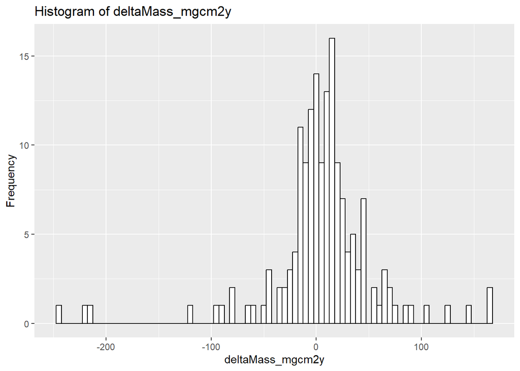

### 1.5.2 deltaVolume_mm3cm2y

List tags where deltaVolume_mm3cm2y = “NA”:

```
## [1] 4880 4895 6751
```

Historgram of deltaVolume_mm3cm2y values

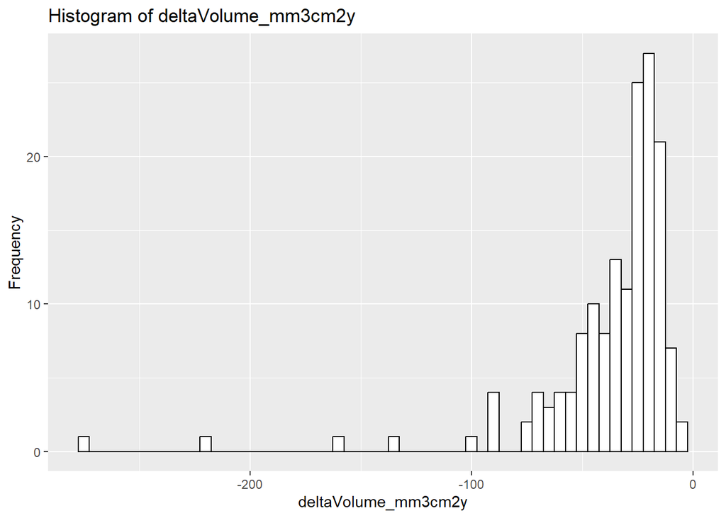

### 1.5.3 deltaDensity_mgcm3cm2y

List tags where deltaDensity_mgcm3cm2y = “NA”:

```
## [1] 4880 4895 6751
```

Historgram of deltaDensity_mgcm3cm2y values

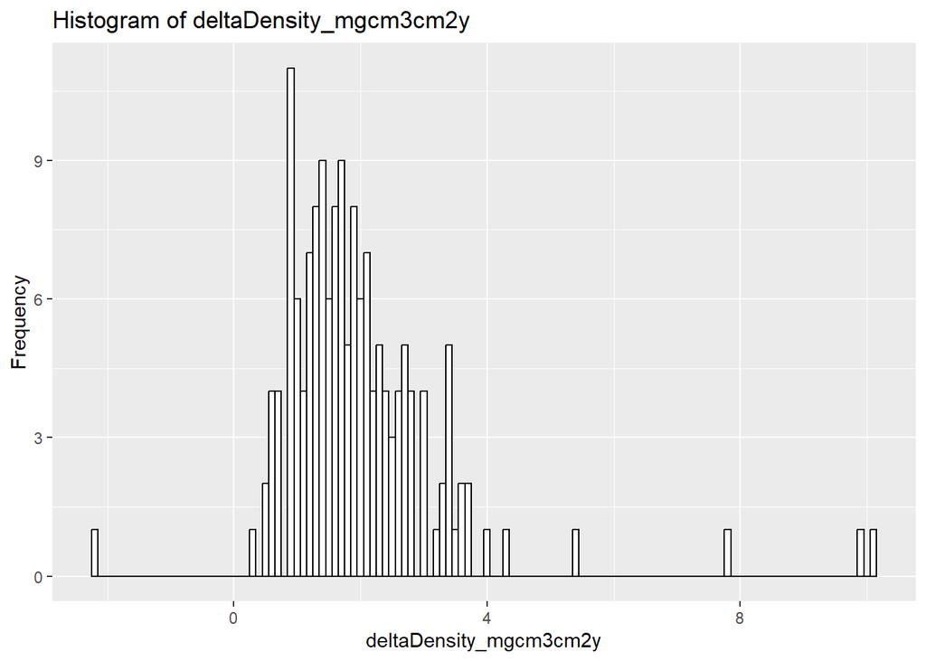

### 1.5.4 macroboring_mm3cm2y

List tags where macroboring_mm3cm2y = “NA”:

```
## [1] 6751
```

Historgram of macroboring_mm3cm2y values

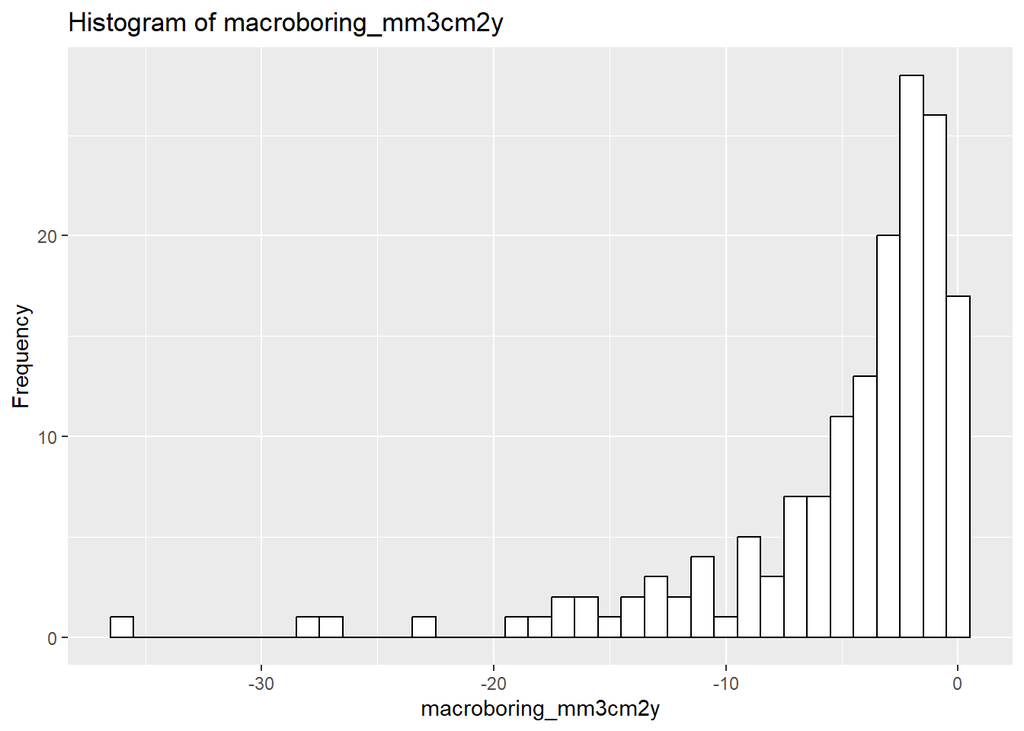

### 1.5.5 grazing_mm3cm2y

List tags where grazing_mm3cm2y = “NA”:

```
## [1] 4880 4895 6751
```

List tags where grazing_mm3cm2y > 0 and list of those values:

```
## numeric(0)
```

```
## numeric(0)
```

Historgram of grazing_mm3cm2y values

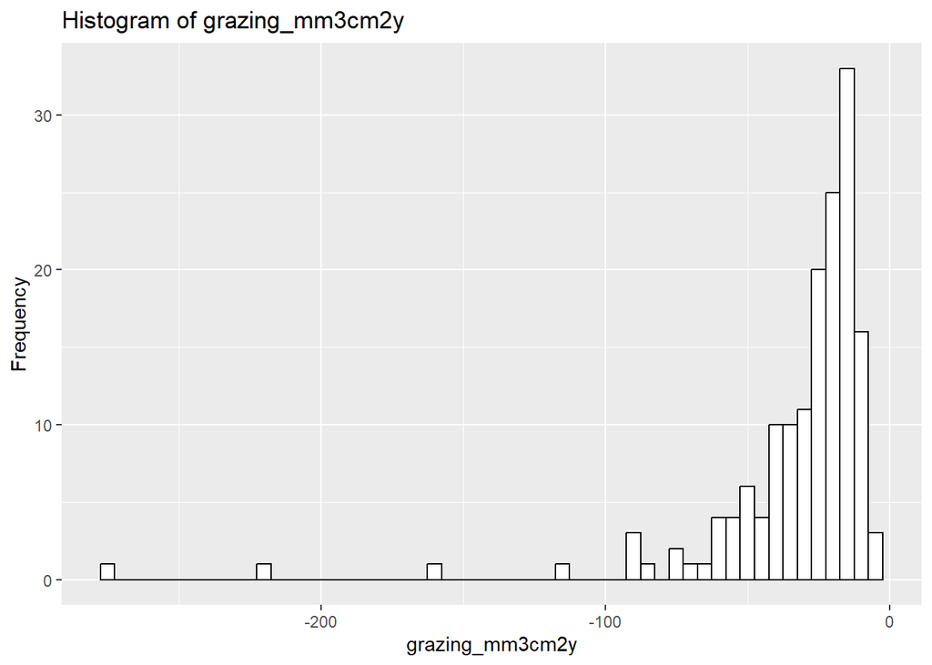

Create grazing specific datasets for subsequent analysis by removing St. Thomas and French Frigate Shoals

### 1.5.6 accretion_mm3cm2y

List tags where accretion_mm3cm2y = “NA”:

```
## [1] 6751
```

Historgram of accretion_mm3cm2y values

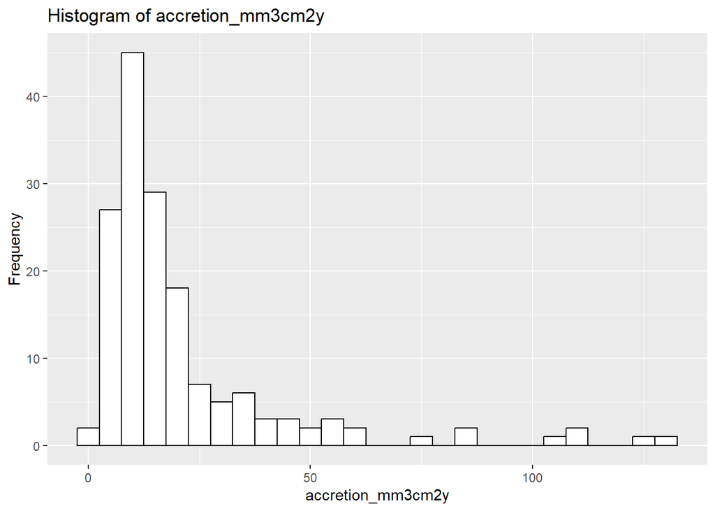

## 1.6 Volume vs. Mass

Plot of deltaVolume_mm3cm2y vs. deltaMass_mgcm2y:

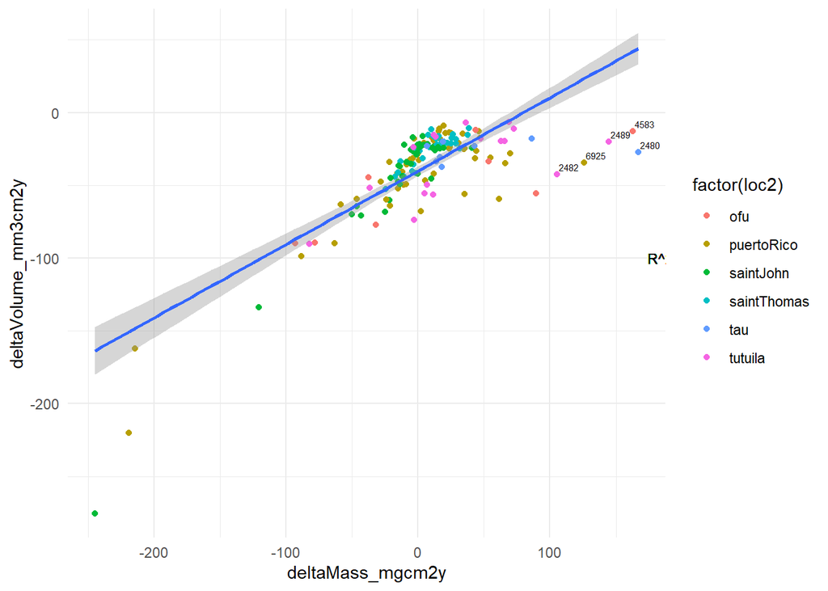

## 1.7 Influence of duration

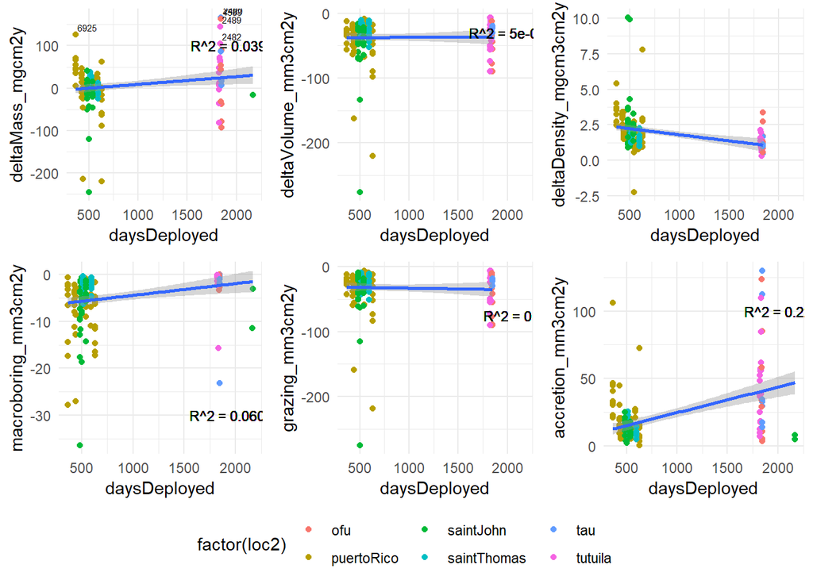

# 2 Global spatial analysis

## 2.1 deltaMass_mgcm2y

deltaMass_mgcm2y boxplots by region and subregion

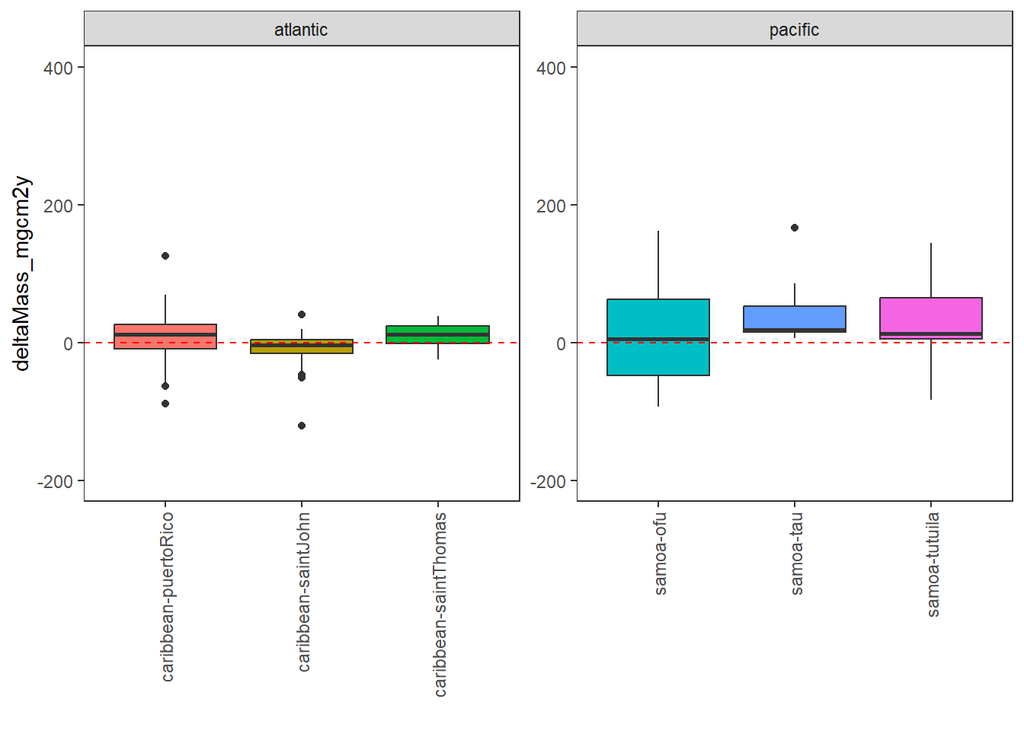

## 2.2 deltaVolume_mm3cm2y

deltaVolume_mm3cm2y boxplots by region and subregion

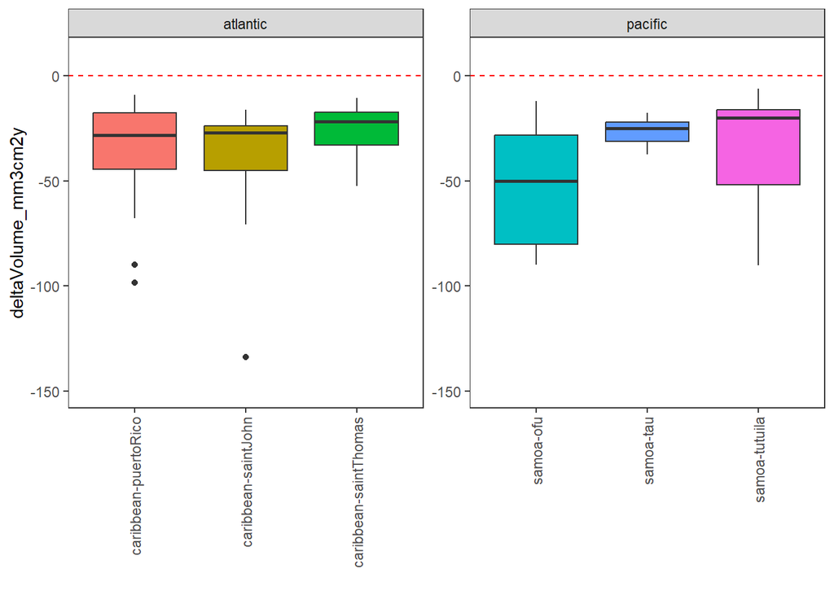

## 2.3 deltaDensity_mgcm3cm2y

deltaDensity_mgcm3cm2y boxplots by region and subregion

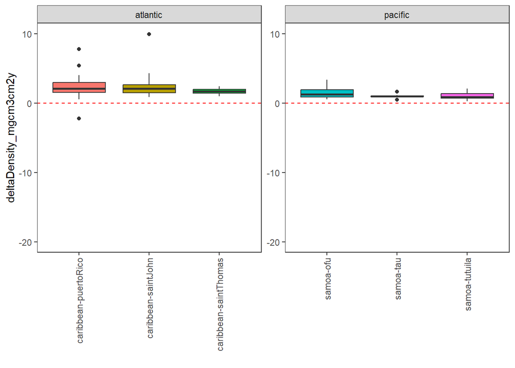

## 2.4 macroboring_mm3cm2y

Macroboring boxplots by region and subregion

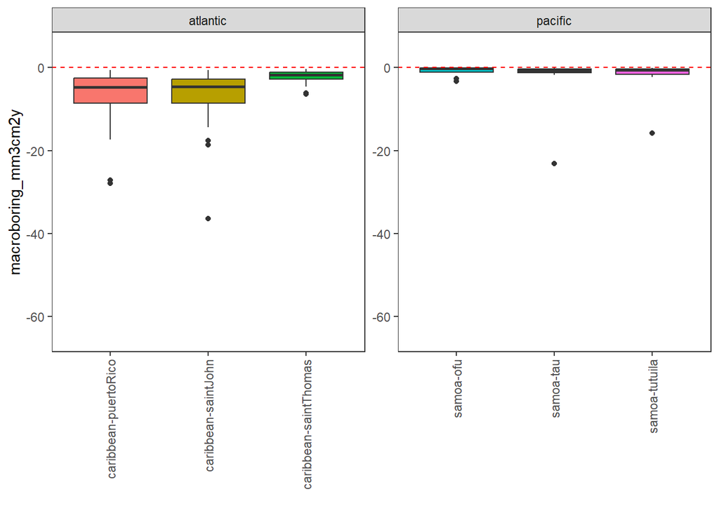

## 2.5 grazing_mm3cm2y

Grazing boxplots by region and subregion CHECK THIS YO *Note that the initial volumes are missing for some USVI and PR data, thereby removing some of those grazing values.

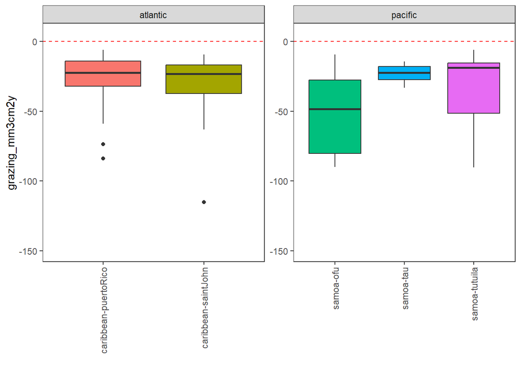

## 2.6 accretion_mm3cm2y

Accretion boxplots by region and subregion

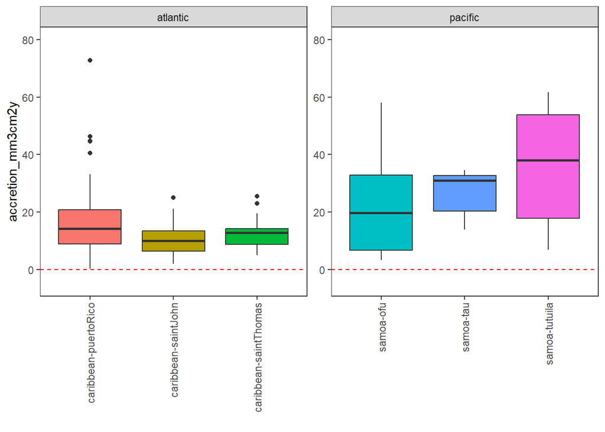

# 3 Exploration of grazing

Note: need to use datasets where all St. Thomas and all French Frigate Shoals data have been removed because of replication These are allBarData_grazingAnalysis, siteBarStats_grazingAnalysis, and grazingParrotStats_grazingAnalysis

## 3.1 Grazing vs. BAR data

### 3.1.1 Grazing vs. mass change

grazing_mm3cm2y vs. deltaMass_mgcm2y

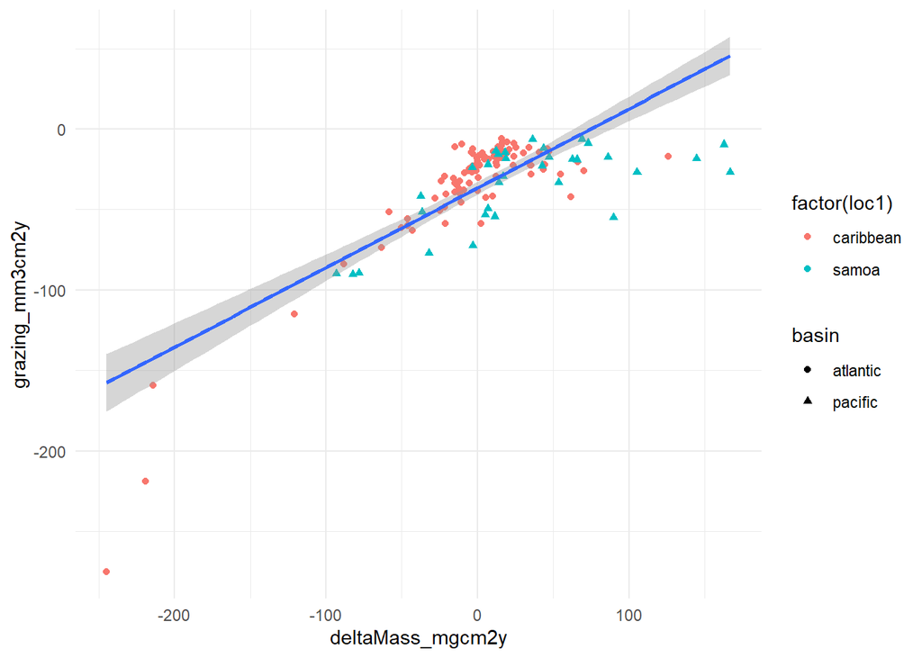

mean grazing_mm3cm2y vs. mean deltaMass_mgcm2y

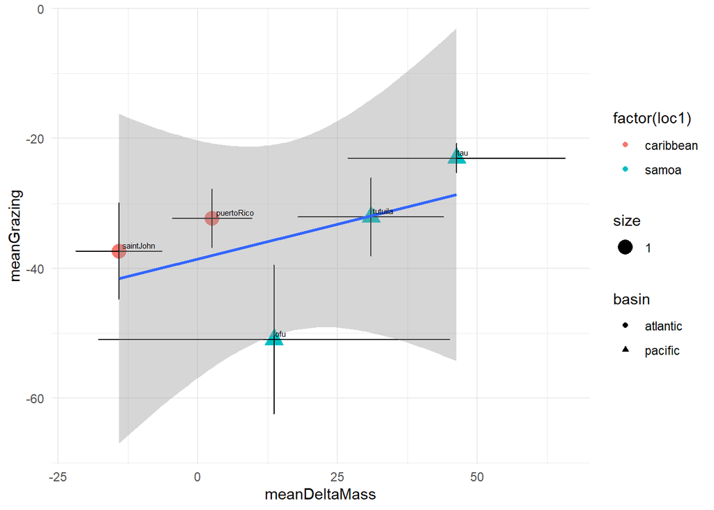

### 3.1.2 Grazing vs. volume change

grazing_mm3cm2y vs. deltaVolume_mm3cm2y

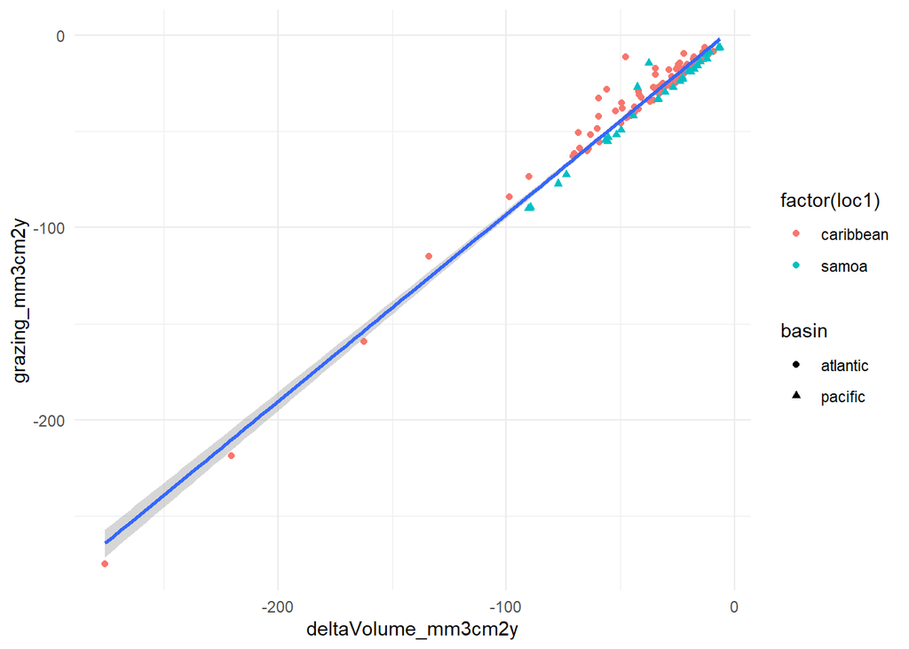

mean grazing_mm3cm2y vs. mean deltaVolume_mm3cm2y

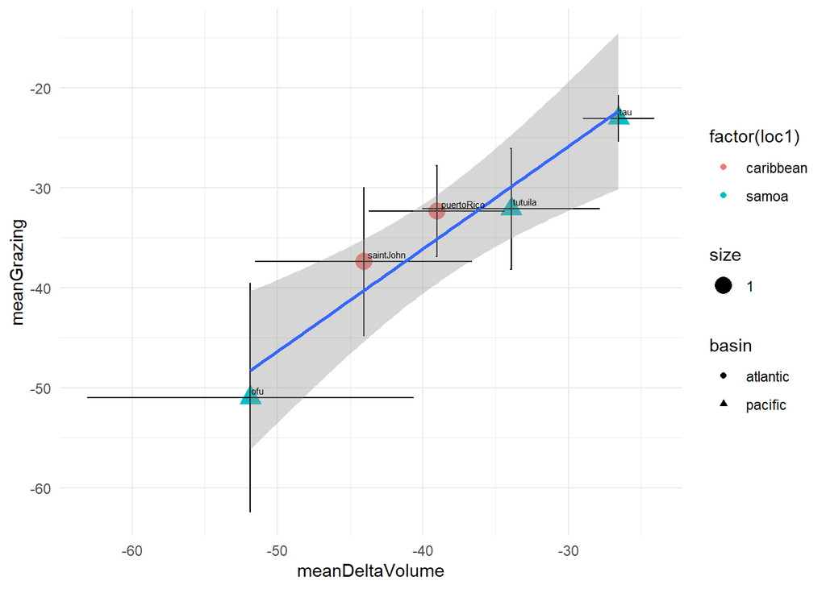

### 3.1.3 Grazing vs. density change

grazing_mm3cm2y vs. deltaDensity_mgcm3cm2y

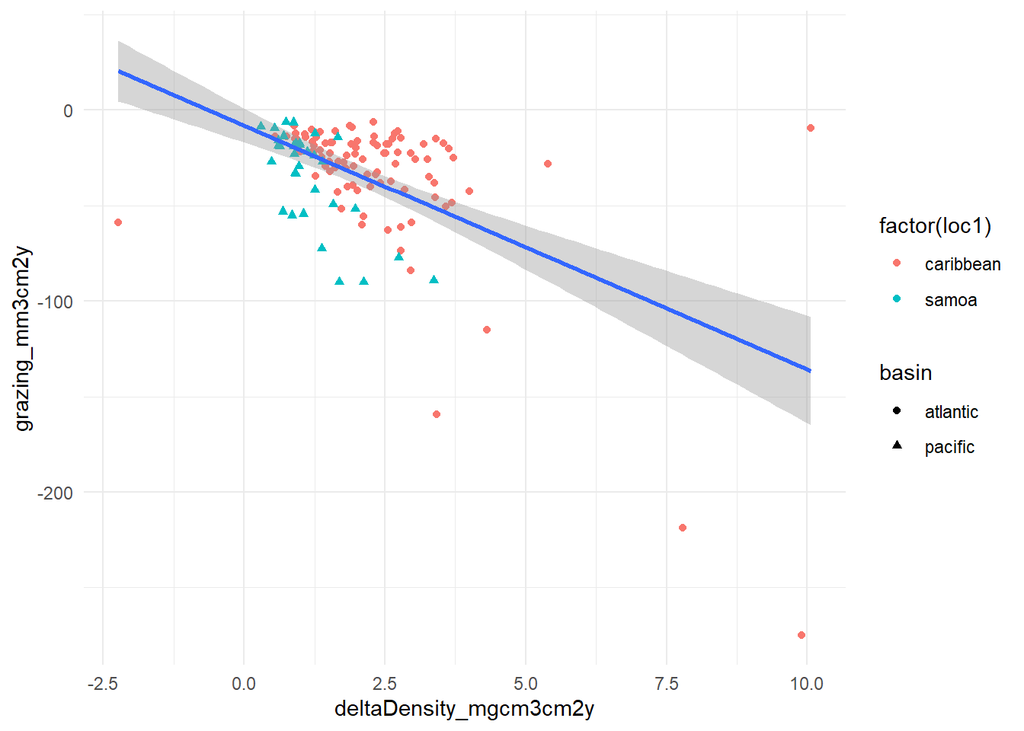

mean grazing_mm3cm2y vs. mean deltaDensity_mgcm3cm2y

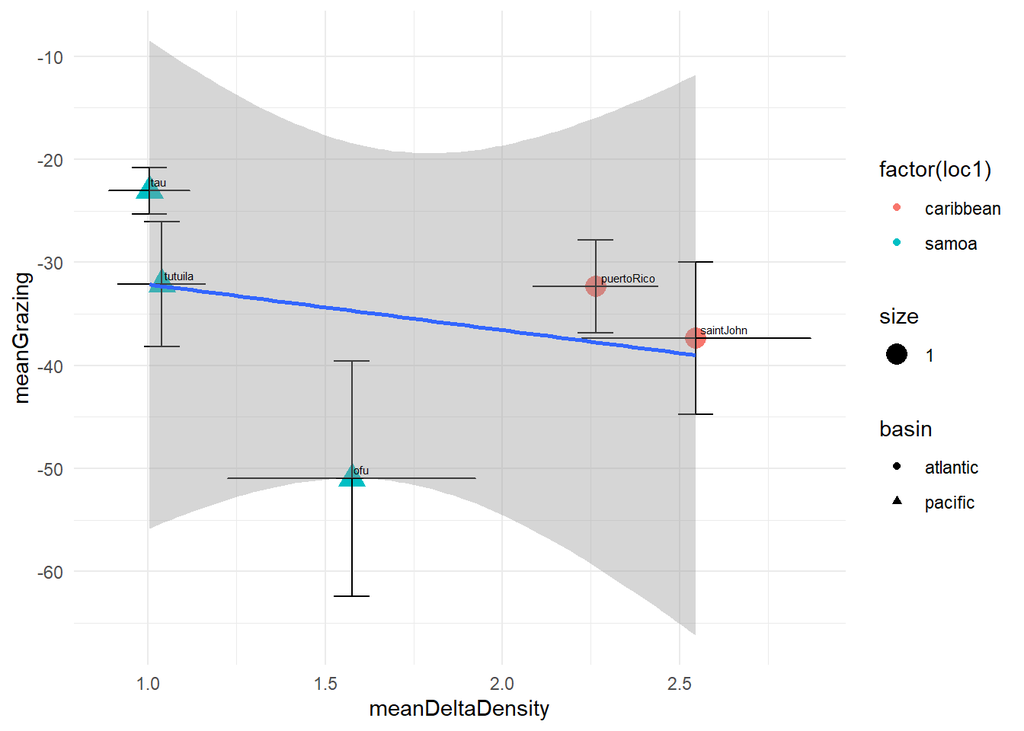

### 3.1.4 Grazing vs. macroboring

grazing_mm3cm2y vs. macroboring_mm3cm2y

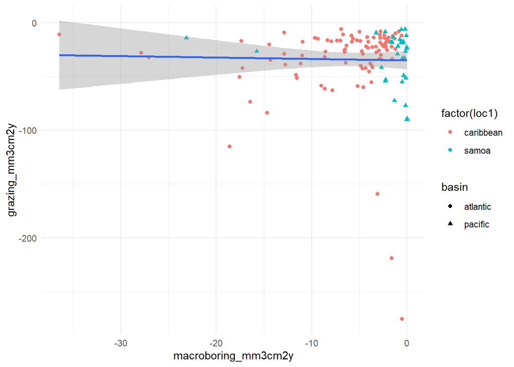

mean grazing_mm3cm2y vs. mean macroboring_mm3cm2y

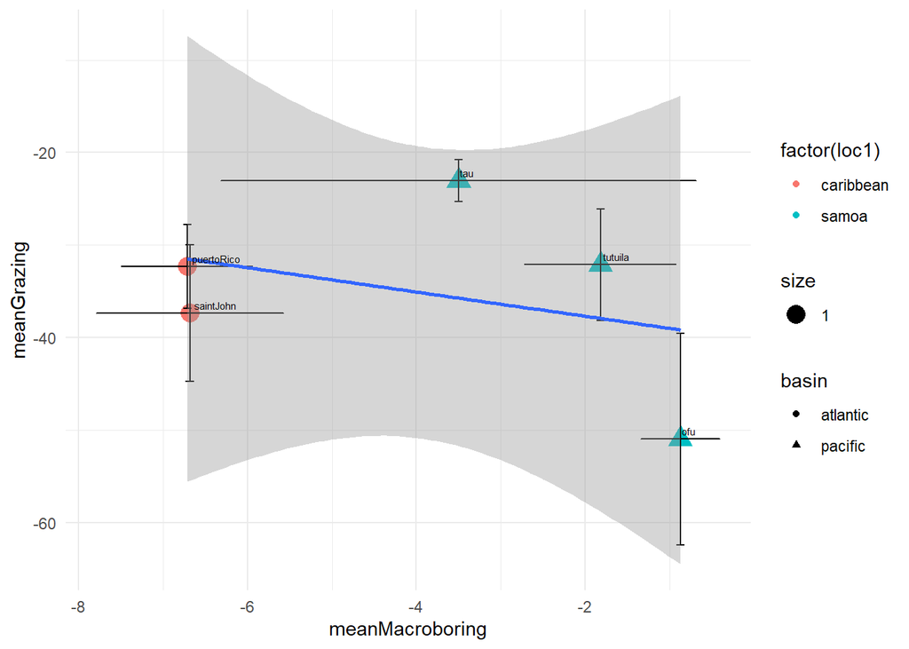

### 3.1.5 Grazing vs. accretion

grazing_mm3cm2y vs. accretion_mm3cm2y

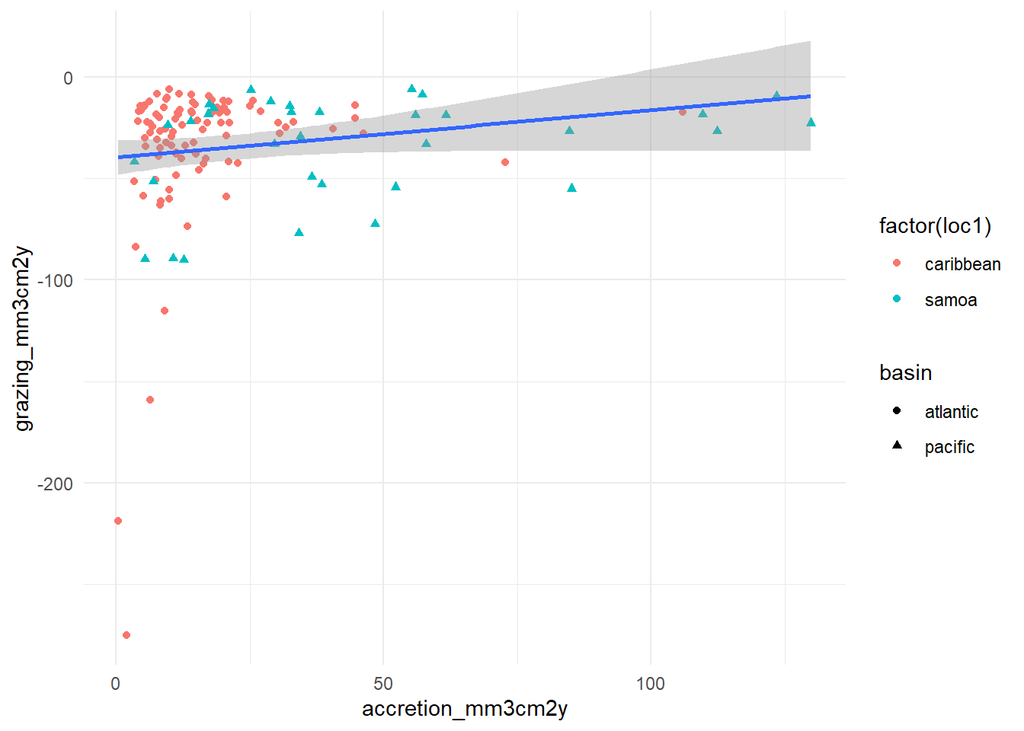

mean grazing_mm3cm2y vs. mean accretion_mm3cm2y

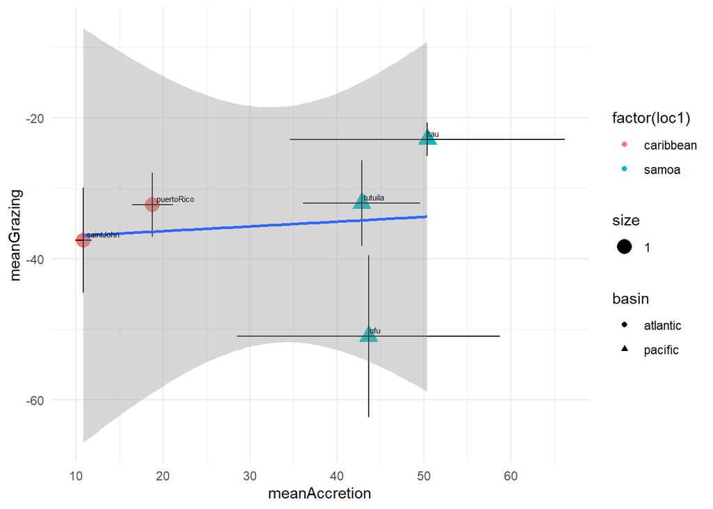

## 3.2 Grazing rates vs parrot community

### 3.2.1 Grazing vs parrot biomass

Mean grazing vs parrot biomass_kg_ha

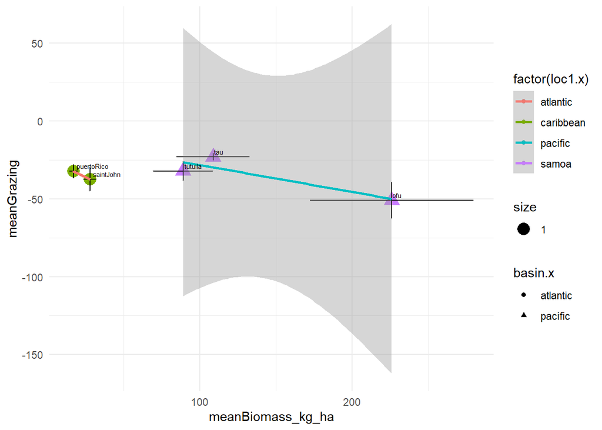

### 3.2.2 Grazing vs parrot density

Mean grazing vs parrot density_ind_ha

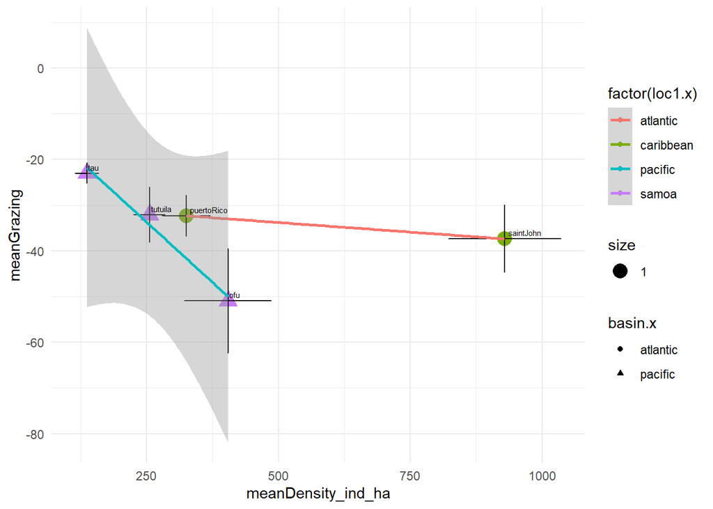